# Two-Sample Means (Dependent) - Week 2, Lecture 2

Author

Dr. Seals

```r
library(tidyverse)
library(gsheet)
```

**A new 2 hour reading comprehension program has been developed by a local tutoring center. A pilot study of 30 students has been conducted and we have data on a reading comprehension test taken before the program and a separate reading comprehension test taken after the program. Consider the data, found in the following Google Sheet.**

```r
data <- as_tibble(gsheet2tbl("https://docs.google.com/spreadsheets/d/1ijxX7c6qcFAw-r_mNSxC-Ps5b5njw-WtE4RcxPTySXU/edit?usp=sharing"))
```

#### 1. Summarize the data. Provide appropriate summary statistics for the study population.

```r
data <- data %>%
  mutate(Diff = Post - Pre)

data %>%
  summarize(PreMean = mean(Pre),
            PreSD = sd(Pre),
            PostMean = mean(Post),
            PostSD = sd(Post),
            DiffMean = mean(Diff),
            DiffSD = sd(Diff))
```

```
# A tibble: 1 × 6
  PreMean PreSD PostMean PostSD DiffMean DiffSD
    <dbl> <dbl>    <dbl>  <dbl>    <dbl>  <dbl>
1    71.4  11.4     75.2   13.3      3.8   4.21
```

#### 2. Construct the 95% confidence interval for the difference in test scores. Hint: we want to discuss this in terms of the *increase* in test scores.

```r
t.test(data$Post, data$Pre, paired = TRUE)
```

```
    Paired t-test

data:  data$Post and data$Pre
t = 4.9496, df = 29, p-value = 2.918e-05
alternative hypothesis: true mean difference is not equal to 0
95 percent confidence interval:
 2.229795 5.370205
sample estimates:
mean difference
            3.8
```

The resulting 95% CI is (2.23, 5.37). That is, the program increases reading scores by 2.23 to 5.37 points.

Instructor’s note: Because we are looking at how the program may have affected reading scores, we want to specifically subtract Post - Pre.

#### 3. Use the appropriate hypothesis test to determine if the program raises comprehension test averages by at least 5 points. Test at the α=0.05 level.

```r
t.test(data$Post, data$Pre, mu = 5, alternative = "greater", paired = TRUE)
```

```
    Paired t-test

data:  data$Post and data$Pre
t = -1.563, df = 29, p-value = 0.9356
alternative hypothesis: true mean difference is greater than 5
95 percent confidence interval:
 2.495512      Inf
sample estimates:
mean difference
            3.8
```

**Test Statistic**

- $t_0 = -1.563$

*p*-Value

- $p = 0.9356$

**Conclusion/Interpretation**

- Fail to reject $H_0$ at the $\alpha=0.05$ level. There is not sufficient evidence to suggest that the reading program is increasing scores by 5 points or more.

#### 4. (Challenge!) Construct a graph that will help you explain your findings to the tutoring center.

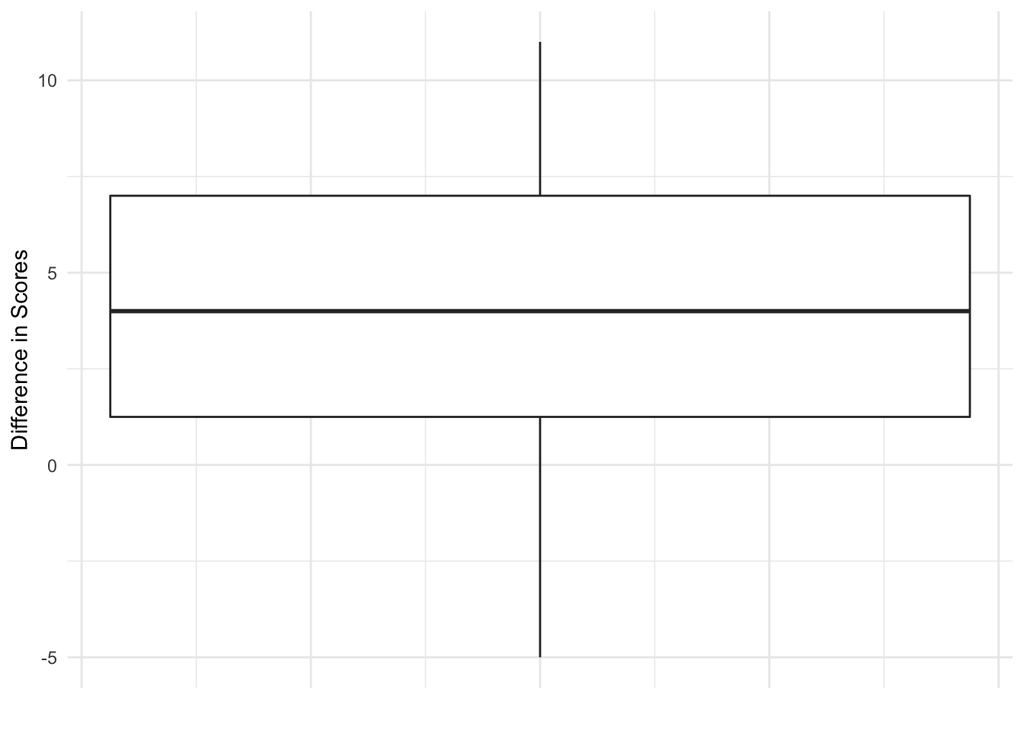

```r
data %>% ggplot(aes(y = Diff)) +
  geom_boxplot() +
  labs(x = "",
       y = "Difference in Scores") +
  theme_minimal() +
  theme(axis.ticks.x = element_blank(),
        axis.text.x = element_blank())
```

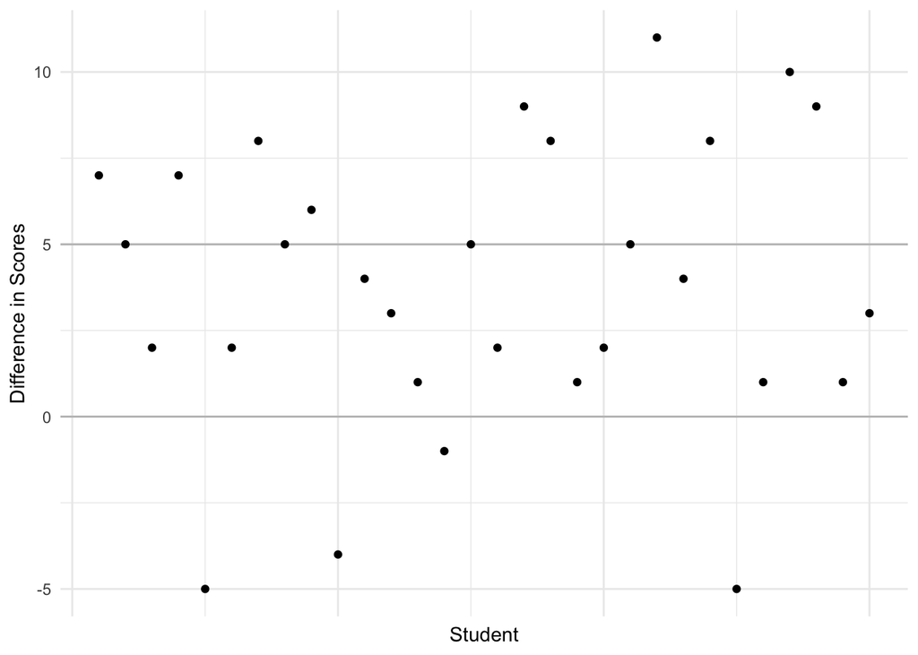

```r
data %>% ggplot(aes(y = Diff, x = Student)) +
  geom_hline(yintercept = 5, color = "gray") +
  geom_point() +
  geom_hline(yintercept = 0, color = "gray") +
  labs(x = "Student",
       y = "Difference in Scores") +
  theme_minimal() +
  theme(axis.ticks.x = element_blank(),
        axis.text.x = element_blank())
```

#### 5. Write a brief paragraph explaining your findings to the tutoring center.

While there is definitely an increase in test scores – the confidence interval (2.23, 5.37) indicates that students will increase somewhere between 2 and 5 points – the average increase is 3.8, which is not larger than 5 points (*p*=0.936). We should note that while most students increased their score somewhat, a handful (*n*=4, 13%) did *not* increase their score. This is a small sample size, so it’s hard to say if they are outliers or if we can truly expect 13% of students to not increase their scores at all.